# Catalog_inflammation

### clusterProfiler

We perform a Over-Representation Analysis (ORA) using the Uniprot IDs.

```r
# Run enrichment
kegg_res <- enrichKEGG(gene = genes_uniprot, organism = "hsa", keyType = "uniprot",
                       pvalueCutoff = 0.05, pAdjustMethod = "BH", qvalueCutoff = 0.05)
```

```
## Reading KEGG annotation online: "https://rest.kegg.jp/link/hsa/pathway"...
```

```
## Reading KEGG annotation online: "https://rest.kegg.jp/list/pathway/hsa"...
```

```
## Reading KEGG annotation online: "https://rest.kegg.jp/conv/uniprot/hsa"...
```

Create some plots to explore the enrichment.

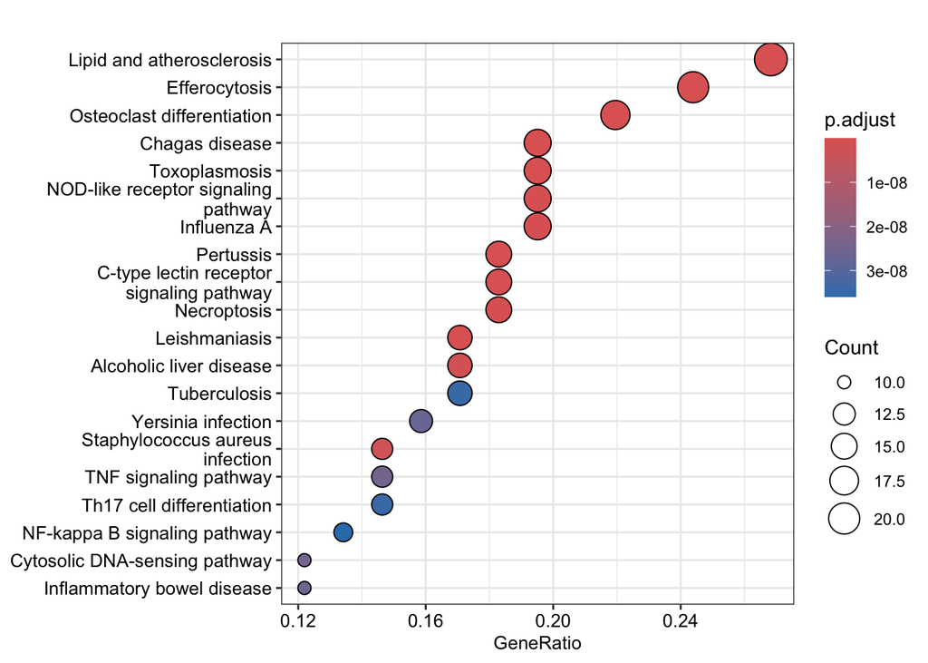

```r
# Plot enriched dotplot
#use: label_format = funlab
#x = ~ -log(p.adjust),
#check in output: only pathways or phenotypes?
dotplot(kegg_res, showCategory = 20, font.size = 10)
```

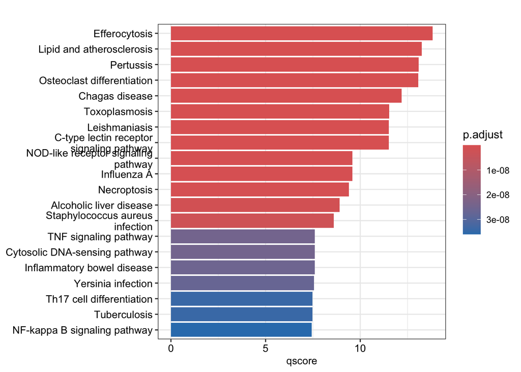

```r
# Plot barplot
kegg_res %>%
  mutate(qscore = -log(p.adjust, base = 10)) %>%
  barplot(x = "qscore", showCategory = 20, font.size = 10)
```

```r
# Plot the most significant terms and their relationships
#kegg_simmat <- pairwise_termsim(kegg_res, method = "JC")
#ssplot(kegg_simmat)
```

### Local enrichment

First, we convert list of genes from Uniprot IDs to KEGG IDs.

```r
kegg_genes <- bitr_kegg(geneID = genes_uniprot, fromType = "uniprot", toType = "kegg", organism = "hsa")
```

```
## Reading KEGG annotation online: "https://rest.kegg.jp/conv/uniprot/hsa"...
```

```r
# Check duplicated entries (genes associated with more than one KEGG ID)
print(unique(kegg_genes$uniprot[duplicated(kegg_genes$uniprot)]))
```

```
## [1] "P0C0L4" "P0C0L5"
```

```r
#kegg_genes <- kegg_genes %>% distinct(kegg, .keep_all = TRUE)

# Update the initial list with KEGG IDs
genes_file <- left_join(genes_file, kegg_genes, by = "uniprot")
```

Our list now contains a total of 87 genes because two of them (P0C0L4 and P0C0L5) are associated with two KEGG IDs each.

#### KEGG KO approach

Next, we use those IDs to get the KEGG KOs.

```r
# Append organism prefix to each entry
genes_map <- kegg_genes %>% pull(kegg)
genes_map <- append(genes_map, list(paste0("hsa:", genes_map)))
genes_map <- unlist(tail(genes_map, 1)) #keep last position
head(genes_map)
```

```
## [1] "hsa:100293534" "hsa:1026"      "hsa:10318"     "hsa:10461"
## [5] "hsa:114548"    "hsa:1240"
```

```r
# Convert KEGG IDs to KOs -> https://www.genome.jp/dbget-bin/www_bget?hsa:721
kegg_kos <- keggLink("ko", genes_map)

# Check duplicated entries
print(kegg_kos[duplicated(kegg_kos)])
```

```
##     hsa:720     hsa:721     hsa:721
## "ko:K03989" "ko:K03989" "ko:K03989"
```

```r
# Create table and export it to file
kegg_id_ko <- tibble(ID = names(kegg_kos), KO = unname(kegg_kos))
kegg_id_ko <- kegg_id_ko %>%
  dplyr::mutate(ID = str_replace(ID, "hsa:", ""), #remove prefix
                KO = str_replace(KO, "ko:", ""))
#write.table(kegg_id_ko, "enrichKEGG/data/KEGG_id2ko.tsv", sep = "\t", quote = FALSE, row.names = FALSE)

# Update the initial list with KEGG KOs
genes_file <- genes_file %>%
  dplyr::rename(kegg_id = kegg) %>%
  left_join(kegg_id_ko %>% distinct(ID, KO), by = join_by(kegg_id == ID)) %>%
  dplyr::rename(kegg_ko = KO)
```

Among these, the same KO (K03989) is assigned to two different KEGG IDs, both corresponding to complement component 4 (C4; C4A and C4B). So, we have 84 unique KOs. The next step is to map the KEGG pathways based on the converted KOs to determine which pathways are represented by our set of genes.

```r
kegg_ko_path <- keggLink("pathway", kegg_kos)
kegg_data <- tibble(KO = names(kegg_ko_path), pathway = unname(kegg_ko_path))

# Which KOs are missing? (not associated with any pathway)
print(kegg_kos[!kegg_kos %in% kegg_data$KO])
```

```
##    hsa:1240    hsa:1773     hsa:325
## "ko:K04245" "ko:K11994" "ko:K23267"
```

```r
print(length(unique(kegg_data$KO))) #81
```

```
## [1] 81
```

We observe that three KOs (K04245, K11994, and K23267) are not associated with any KEGG pathway, and were therefore excluded from the pathway-based analysis. This reduces the set to 81 KOs.

```r
# Modify and filter columns
kegg_data <- kegg_data %>%
  dplyr::mutate(KO = str_replace(KO, "ko:", "")) %>%
  dplyr::mutate(pathway = str_replace(pathway, "path:map", "")) %>% #keep map?
  dplyr::filter(!grepl("ko", pathway))

# Check the pathway names from the KEGG database (v.042022)
#pathway_list <- read.csv("enrichKEGG/data/pathway.list.mod.tsv", sep = "\t", header = TRUE,
#                         colClasses = c("character", "character"), stringsAsFactors = FALSE)
#print(kegg_categories[!(kegg_categories$id %in% pathway_list$id), ]) #ie. 04148 --> Efferocytosis

# Get KEGG pathway names from API
kegg_categories <- clusterProfiler:::kegg_category_data()
kegg_data <- left_join(kegg_data, kegg_categories, by = join_by(pathway == id))

# Process NAs manually
#https://www.kegg.jp/pathway/map<pathway>
#https://www.genome.jp/kegg/docs/upd_kegg.html
print(kegg_data %>% filter(is.na(name)) %>% distinct(pathway))
```

```
## # A tibble: 5 × 1
##   pathway
##   <chr>
## 1 04081
## 2 04082
## 3 04519
## 4 04517
## 5 04518
```

```r
kegg_data <- kegg_data %>%
  dplyr::mutate(name = str_replace(name, "Efferocytosis New!", "Efferocytosis")) %>% #edit name
  dplyr::mutate(name = case_when(pathway == "04081" ~ "Hormone signaling",
                                 pathway == "04082" ~ "Neuroactive ligand signaling",
                                 pathway == "04517" ~ "IgSF CAM signaling",
                                 pathway == "04518" ~ "Integrin signaling",
                                 pathway == "04519" ~ "Cadherin signaling",
                                 TRUE ~ name)) %>%
  dplyr::mutate(subcategory = case_when(pathway == "04081" ~ "Signaling molecules and interaction",
                                        pathway == "04082" ~ "Signaling molecules and interaction",
                                        pathway == "04517" ~ "Signaling molecules and interaction",
                                        pathway == "04518" ~ "Signaling molecules and interaction",
                                        pathway == "04519" ~ "Signaling molecules and interaction",
                                        TRUE ~ subcategory)) %>%
  dplyr::mutate(category = case_when(pathway == "04081" ~ "Environmental Information Processing",
                                     pathway == "04082" ~ "Environmental Information Processing",
                                     pathway == "04517" ~ "Environmental Information Processing",
                                     pathway == "04518" ~ "Environmental Information Processing",
                                     pathway == "04519" ~ "Environmental Information Processing",
                                     TRUE ~ category))

#get KO name? *** ej. K03989 -> C4; complement component 4
```

We plot the global distribution of KEGG pathways.

```
## Defaulting to continuous.
## Defaulting to continuous.
```

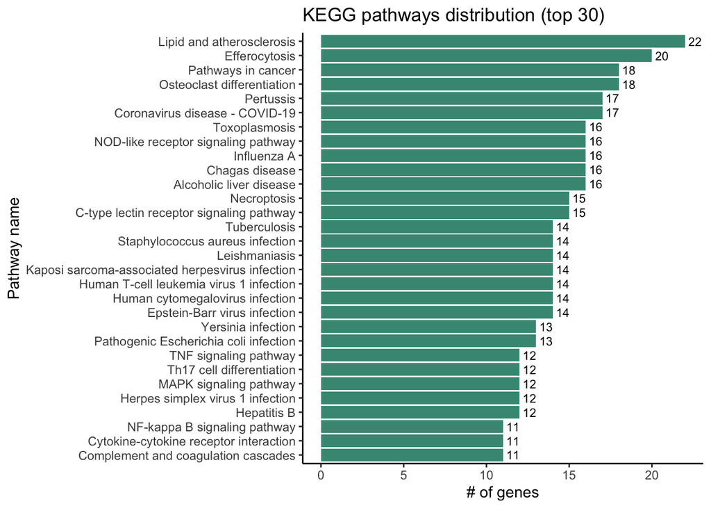

```r
kegg_data %>%
  dplyr::group_by(pathway, name) %>%
  dplyr::summarise(n_path = table(pathway), .groups = "drop") %>%
  dplyr::arrange(desc(n_path)) %>%
  dplyr::slice(1:30) %>% #top 30
  ggplot(aes(x = n_path, y = fct_reorder(name, n_path))) + #, fill = name
  geom_col(position = "dodge2", fill = "#459682") +
  #scale_fill_discrete_diverging(name = "", palette = "Purple-Green") +
  geom_text(aes(label = n_path), vjust = 0.5, hjust = -0.25, size = 3) +
  labs(title = "KEGG pathways distribution (top 30)", x = "# of genes", y = "Pathway name") +
  theme_classic() +
  theme(legend.position = "none")
```

```
## Defaulting to continuous.
## Defaulting to continuous.
```

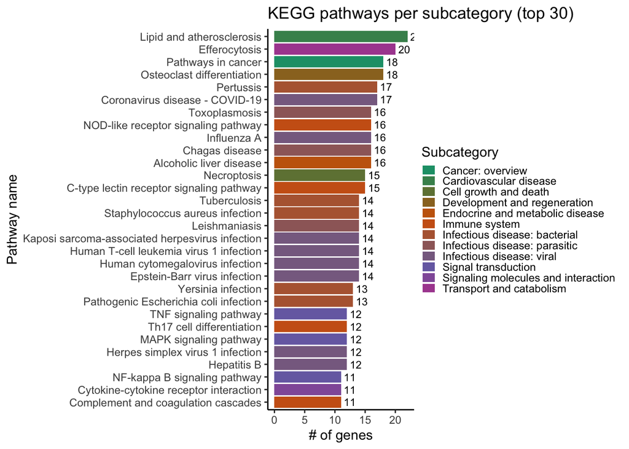

```r
# Set colors for subcategories
colors_subcat <- brewer.dark2(length(unique(kegg_data$subcategory)))

# Group by subcategory
kegg_data %>%
  dplyr::group_by(pathway, subcategory, name) %>%
  dplyr::summarise(n_path = table(pathway), .groups = "drop") %>%
  dplyr::arrange(desc(n_path)) %>%
  dplyr::slice(1:30) %>% #top 30
  ggplot(aes(x = n_path, y = fct_reorder(name, n_path), fill = subcategory)) +
  geom_col(position = "dodge2") +
  geom_text(aes(label = n_path), vjust = 0.5, hjust = -0.25, size = 3) +
  scale_fill_manual(name = "Subcategory", values = colors_subcat) +
  labs(title = "KEGG pathways per subcategory (top 30)", x = "# of genes", y = "Pathway name") +
  theme_classic() +
  theme(legend.box.spacing = unit(0.5, "pt"), #space between tree and legend
        legend.key.spacing.x = unit(0.1, "pt"), #space between columns
        legend.key.spacing.y = unit(0.1, "pt"), #space between rows
        legend.spacing.y = unit(0.75, "pt"), #space between legend titles
        legend.key.height = unit(3, units = "mm"),
        legend.key.width = unit(4, units = "mm"))
```

```
## Defaulting to continuous.
## Defaulting to continuous.
```

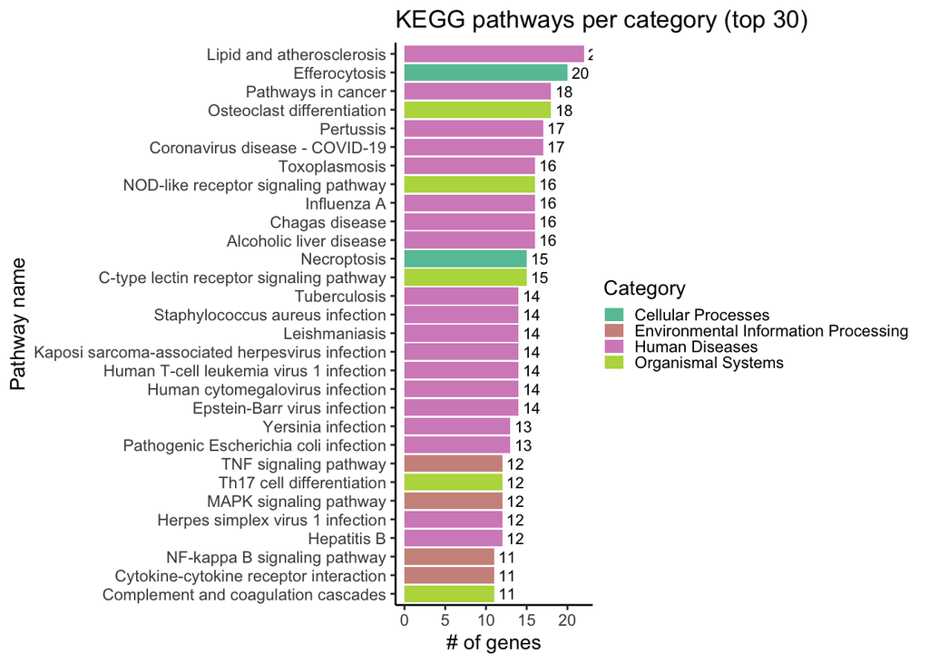

```r
# Set colors for categories
colors_cat <- colorRampPalette(brewer.pal(8, "Set2"))(length(unique(kegg_data$category)))

# Group by category
kegg_data %>%
  dplyr::group_by(pathway, category, name) %>%
  dplyr::summarise(n_path = table(pathway), .groups = "drop") %>%
  dplyr::arrange(desc(n_path)) %>%
  dplyr::slice(1:30) %>% #top 30
  ggplot(aes(x = n_path, y = fct_reorder(name, n_path), fill = category)) +
  geom_col(position = "dodge2") +
  geom_text(aes(label = n_path), vjust = 0.5, hjust = -0.25, size = 3) +
  scale_fill_manual(name = "Category", values = colors_cat) +
  labs(title = "KEGG pathways per category (top 30)", x = "# of genes", y = "Pathway name") +
  theme_classic() +
  theme(legend.box.spacing = unit(0.5, "pt"), #space between tree and legend
        legend.key.spacing.x = unit(0.1, "pt"), #space between columns
        legend.key.spacing.y = unit(0.1, "pt"), #space between rows
        legend.spacing.y = unit(0.75, "pt"), #space between legend titles
        legend.key.height = unit(3, units = "mm"),
        legend.key.width = unit(4, units = "mm"))
```

At this point, the dataset comprises a total of 215 pathways. But, there are some pathways derived from ortholog genes belonging to other organisms. For instance, “MAPK signaling pathway - fly” (04013), “Meiosis - yeast” (04113), “Longevity regulating pathway - worm” (04212), or “Apoptosis - fly” (04214).

#### KEGG ID approach

Lets try with the mapping of KEGG pathways by using directly the IDs (skipping ortholog (KO) convertion)…

```r
kegg_id2path <- keggLink("pathway", genes_map)
kegg_data_id <- tibble(ID = names(kegg_id2path), pathway = unname(kegg_id2path))

# Which KEGG IDs are missing? (not associated with any pathway)
print(genes_map[!genes_map %in% kegg_data_id$ID])
```

```
## [1] "hsa:1240" "hsa:1773" "hsa:325"
```

```r
print(length(unique(kegg_data_id$ID))) #83
```

```
## [1] 83
```

We observe the same three genes (1240: K04245, 1773: K11994, and 325: K23267) that are not associated with any KEGG pathway. This reduces the set to 83 KEGG IDs.

```r
# Modify and filter columns
kegg_data_id <- kegg_data_id %>%
  dplyr::mutate(ID = str_replace(ID, "hsa:", "")) %>%
  dplyr::mutate(pathway = str_replace(pathway, "path:hsa", ""))

# Get KEGG pathway names from API
kegg_data_id <- left_join(kegg_data_id, kegg_categories, by = join_by(pathway == id))

# Curate NAs manually
#https://www.kegg.jp/pathway/map<pathway>
#https://www.genome.jp/kegg/docs/upd_kegg.html
print(kegg_data_id %>% dplyr::filter(is.na(name)) %>% distinct(pathway))
```

```
## # A tibble: 5 × 1
##   pathway
##   <chr>
## 1 04081
## 2 04082
## 3 04519
## 4 04517
## 5 04518
```

```r
kegg_data_id <- kegg_data_id %>%
  dplyr::mutate(name = str_replace(name, "Efferocytosis New!", "Efferocytosis")) %>% #edit name
  dplyr::mutate(name = case_when(pathway == "04081" ~ "Hormone signaling",
                                 pathway == "04082" ~ "Neuroactive ligand signaling",
                                 pathway == "04517" ~ "IgSF CAM signaling",
                                 pathway == "04518" ~ "Integrin signaling",
                                 pathway == "04519" ~ "Cadherin signaling",
                                 TRUE ~ name)) %>%
  dplyr::mutate(subcategory = case_when(pathway == "04081" ~ "Signaling molecules and interaction",
                                        pathway == "04082" ~ "Signaling molecules and interaction",
                                        pathway == "04517" ~ "Signaling molecules and interaction",
                                        pathway == "04518" ~ "Signaling molecules and interaction",
                                        pathway == "04519" ~ "Signaling molecules and interaction",
                                        TRUE ~ subcategory)) %>%
  dplyr::mutate(category = case_when(pathway == "04081" ~ "Environmental Information Processing",
                                     pathway == "04082" ~ "Environmental Information Processing",
                                     pathway == "04517" ~ "Environmental Information Processing",
                                     pathway == "04518" ~ "Environmental Information Processing",
                                     pathway == "04519" ~ "Environmental Information Processing",
                                     TRUE ~ category))
```

We plot the global distribution of KEGG pathways.

```
## Defaulting to continuous.
## Defaulting to continuous.
## Defaulting to continuous.
## Defaulting to continuous.
## Defaulting to continuous.
## Defaulting to continuous.
```

[figure not shown]

```r
#, fig.width = 10, fig.height = 8, out.width = "100%"
p1 <- kegg_data_id %>%
  dplyr::group_by(pathway, name) %>%
  dplyr::summarise(n = table(pathway), .groups = "drop") %>%
  dplyr::arrange(desc(n)) %>%
  dplyr::slice(1:30) %>% #top 30
  ggplot(aes(x = n, y = fct_reorder(name, n))) + #, fill = name
  geom_col(position = "dodge2", fill = "#459682") +
  geom_text(aes(label = n), vjust = 0.5, hjust = -0.25, size = 3) +
  labs(title = "KEGG pathways distribution (top 30)", x = "# of genes", y = "Pathway name") +
  theme_classic() +
  theme(legend.position = "none")

# Set colors for subcategories
colors_subcat <- brewer.dark2(length(unique(kegg_data_id$subcategory)))

# Group by subcategory
p2 <- kegg_data_id %>%
  dplyr::group_by(pathway, subcategory, name) %>%
  dplyr::summarise(n = table(pathway), .groups = "drop") %>%
  dplyr::arrange(desc(n)) %>%
  dplyr::slice(1:30) %>% #top 30
  ggplot(aes(x = n, y = fct_reorder(name, n), fill = subcategory)) +
  geom_col(position = "dodge2") +
  geom_text(aes(label = n), vjust = 0.5, hjust = -0.25, size = 3) +
  scale_fill_manual(name = "Subcategory", values = colors_subcat) +
  labs(title = "KEGG pathways per subcategory (top 30)", x = "# of genes", y = "Pathway name") +
  theme_classic() +
  theme(legend.box.spacing = unit(0.5, "pt"), #space between tree and legend
        legend.key.spacing.x = unit(0.1, "pt"), #space between columns
        legend.key.spacing.y = unit(0.1, "pt"), #space between rows
        legend.spacing.y = unit(0.75, "pt"), #space between legend titles
        legend.key.height = unit(3, units = "mm"),
        legend.key.width = unit(4, units = "mm"))

# Set colors for categories
colors_cat <- colorRampPalette(brewer.pal(8, "Set2"))(length(unique(kegg_data_id$category)))

# Group by category
p3 <- kegg_data_id %>%
  dplyr::group_by(pathway, category, name) %>%
  dplyr::summarise(n = table(pathway), .groups = "drop") %>%
  dplyr::arrange(desc(n)) %>%
  dplyr::slice(1:30) %>% #top 30
  ggplot(aes(x = n, y = fct_reorder(name, n), fill = category)) +
  geom_col(position = "dodge2") +
  geom_text(aes(label = n), vjust = 0.5, hjust = -0.25, size = 3) +
  scale_fill_manual(name = "Category", values = colors_cat) +
  labs(title = "KEGG pathways per category (top 30)", x = "# of genes", y = "Pathway name") +
  theme_classic() +
  theme(legend.box.spacing = unit(0.5, "pt"), #space between tree and legend
        legend.key.spacing.x = unit(0.1, "pt"), #space between columns
        legend.key.spacing.y = unit(0.1, "pt"), #space between rows
        legend.spacing.y = unit(0.75, "pt"), #space between legend titles
        legend.key.height = unit(3, units = "mm"),
        legend.key.width = unit(4, units = "mm"))

# Agglom. plots
(p1 / p2 / p3) + plot_annotation(tag_levels = list(c("a", "b", "c")))
```

```r
ggsave("enrichKEGG/plots/plot_KEGG_pathways.png", height = 15, width = 7)
```

```
## Defaulting to continuous.
## Defaulting to continuous.
## Defaulting to continuous.
## Defaulting to continuous.
## Defaulting to continuous.
## Defaulting to continuous.
```

#### Enrichment

We calculate the enrichment-like ratio of genes per pathway.

```r
kegg_enrichment <- kegg_data_id %>%
  dplyr::group_by(ID, pathway, name) %>% #separate by IDs
  dplyr::summarise(n_paths = n(), .groups = "drop") %>%
  ungroup() %>%
  dplyr::group_by(pathway, name) %>%
  dplyr::summarise(across(ID, \(x) paste(na.omit(x), collapse = ",")),
                   count = n(), .groups = "drop") %>% #collapse IDs by pathway and count them
  ungroup() %>%
  dplyr::rename(geneIDs = ID) %>%
  dplyr::mutate(ratio = count / length(unique(kegg_data_id$ID))) #gene ratio is count/total genes
```

Download the complete KEGG human pathway-to-gene mapping.

```r
kegg_all_hsa <- keggLink("pathway", "hsa")
kegg_mapping <- data.frame(gene_id = gsub("", "", names(kegg_all_hsa)), #hsa:
                           path_id = gsub("path:hsa", "", unname(kegg_all_hsa)))
print(length(unique(kegg_mapping$gene_id))) #total genes
```

```
## [1] 9421
```

We define the actual background universe of pathways and genes per pathway.

```r
# Define the total number of all unique genes in the background distribution
bg_genes <- length(unique(kegg_mapping$gene_id)) #N
kegg_map_path <- kegg_mapping %>%
  dplyr::group_by(path_id) %>%
  dplyr::summarise(M = n()) #number of genes in the background universe (per pathway)

# Merge background data with the enrichment
kegg_enrichment <- kegg_enrichment %>%
  left_join(kegg_map_path, by = join_by(pathway == path_id)) %>%
  dplyr::mutate(BgRatio = paste0(M, "/", bg_genes)) #calculate the BgRatio = M/N
```

Using the background universe, a hypergeometric distribution is applied to calculate the p-value. This statistical test evaluates the significance of the overlap between the gene set and the universe.

```r
# Define the number of genes in the gene set
n_paths <- length(unique(kegg_data_id$pathway)) #n
#phyper(k-1, M, N-M, n, lower.tail = FALSE)
#use correction methods: such as Bonferroni or false discovery rate (FDR)
kegg_enrichment <- kegg_enrichment %>%
  dplyr::mutate(pvalue = phyper(count - 1, M, bg_genes - M, n_paths, lower.tail = FALSE)) %>%
  dplyr::mutate(p.adjust = p.adjust(pvalue, method = "BH"))

# Get and sort the significant pathways
print(kegg_enrichment %>%
        dplyr::filter(pvalue <= 0.05) %>%
        dplyr::select(name, ratio, p.adjust) %>%
        dplyr::arrange(desc(ratio)))
```

```
## # A tibble: 68 × 3
##    name                                ratio      p.adjust
##    <chr>                               <dbl>         <dbl>
##  1 Lipid and atherosclerosis           0.265 0.0000000668
##  2 Efferocytosis                       0.241 0.0000000214
##  3 Osteoclast differentiation          0.217 0.0000000668
##  4 Pathways in cancer                  0.217 0.147
##  5 NOD-like receptor signaling pathway 0.193 0.0000568
##  6 Pertussis                           0.193 0.00000000192
##  7 Chagas disease                      0.193 0.0000000513
##  8 Toxoplasmosis                       0.193 0.0000000783
##  9 Influenza A                         0.193 0.0000240
## 10 Coronavirus disease - COVID-19      0.193 0.000584
## # ℹ 58 more rows
```

We create a dotplot of the local enrichment.

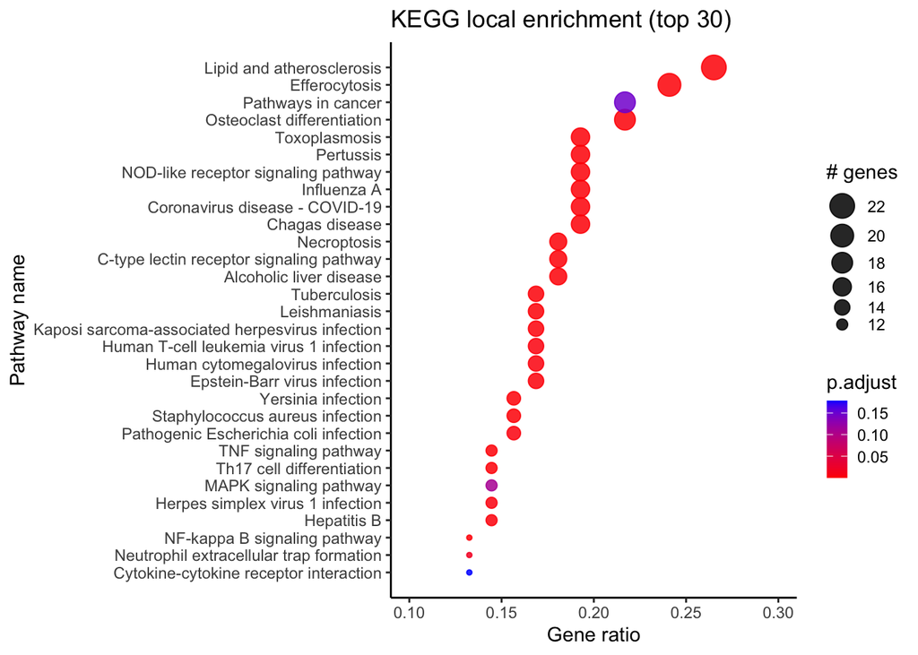

```r
# Helper function to match the gradient colors
#colors_legend <- scales::seq_gradient_pal(low = "red", high = "blue")(seq(0, 1, length.out = 3))

p4 <- kegg_enrichment %>%
  dplyr::arrange(desc(ratio)) %>%
  dplyr::slice(1:30) %>% #top 30
  ggplot(aes(x = ratio, y = fct_reorder(name, ratio))) +
  geom_point(aes(size = count, color = p.adjust), alpha = 0.85) +
  scale_y_discrete(expand = c(0.05, 0)) + #add y-axis space
  scale_x_continuous(limits = c(0.1, 0.3)) +
  scale_color_gradient(name = "p.adjust", low = "red", high = "blue") +
  guides(size = guide_legend(title = "# genes", order = 1, reverse = TRUE,
                             override.aes = list(color = "black", alpha = 0.85))) +
  labs(title = "KEGG local enrichment (top 30)", x = "Gene ratio", y = "Pathway name") +
  theme_classic() +
  theme(legend.key.height = unit(3, units = "mm"),
        legend.key.width = unit(4, units = "mm"))
p4
```

```r
ggsave("enrichKEGG/plots/plot_KEGG_enrichment.png", height = 5, width = 7)
```

We process the genes from the enrichment analysis.

[figure not shown]

```r
kegg_engenes <- kegg_enrichment %>%
  separate_longer_delim(cols = geneIDs, delim = ",") %>% #split 114548,1535,1536,29108,...,
  group_by(geneIDs) %>%
  summarise(genes = n()) %>%
  left_join(kegg_data_id, by = join_by(geneIDs == ID)) #add KEGG data

# Plot all genes across pathways
kegg_engenes %>%
  distinct(geneIDs, .keep_all = TRUE) %>% #collapse list
  left_join(genes_file, by = join_by(geneIDs == kegg_id)) %>% #add gene data from the input list
  dplyr::mutate(gene_lab = paste0(HGNC_symbol, " (KEGG ID: ", geneIDs, ") - ", Main_function)) %>% #label
  arrange(desc(genes)) %>%
  ggplot(aes(x = genes, y = fct_reorder(gene_lab, genes))) +
  geom_point(aes(size = genes, color = category), alpha = 0.75) + #"#e31a1c"
  geom_text(aes(label = genes), vjust = 0.5, hjust = -0.25, size = 3) +
  scale_y_discrete(expand = c(0.025, 0)) + #add y-axis space
  scale_fill_manual(name = "Category", values = colors_cat) +
  guides(size = "none") +
  labs(title = "Inflammatory genes", x = "# of pathways", y = "Gene name and function") +
  theme_classic() +
  theme(legend.box.spacing = unit(0.5, "pt"), #space between tree and legend
        legend.key.spacing.x = unit(0.1, "pt"), #space between columns
        legend.key.spacing.y = unit(0.1, "pt"), #space between rows
        legend.spacing.y = unit(0.75, "pt"), #space between legend titles
        legend.key.height = unit(3, units = "mm"),
        legend.key.width = unit(4, units = "mm"))
```

```r
ggsave("enrichKEGG/plots/plot_KEGG_key_genes.png", height = 15, width = 10)
```

## KEGG statistics

We explore some data in the KEGG database.

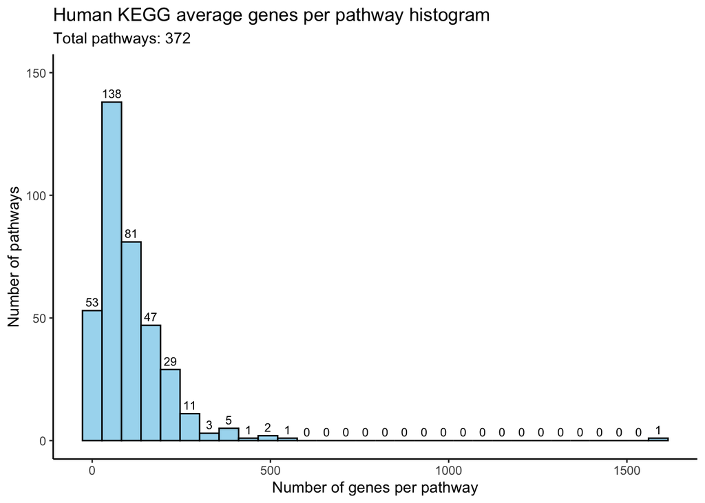

```r
# Count genes per pathway
kegg_genes_per_pathway <- kegg_mapping %>%
  dplyr::group_by(path_id) %>%
  dplyr::summarise(n_genes = n_distinct(gene_id))

# Plot an histogram with the average number of genes per pathways
kegg_genes_per_pathway %>%
  ggplot(aes(x = n_genes)) +
  geom_histogram(bins = 30, color = "black", fill = "skyblue", alpha = 0.75) + #binwidth = 0.2
  stat_bin(aes(label = after_stat(count)), bins = 30, geom = "text", size = 3, vjust = -0.5) +
  scale_y_continuous(limits = c(0, 150)) +
  labs(title = "Human KEGG average genes per pathway histogram",
       subtitle = paste0("Total pathways: ", length(unique(kegg_mapping$path_id))),
       x = "Number of genes per pathway", y = "Number of pathways") +
  theme_classic()
```

```r
ggsave("enrichKEGG/plots/plot_KEGG_stats.png", height = 5, width = 7)
```

## KEGG pathway

Using KEGGgraph package, we explore and manipulate KEGG pathways in a graph-like approach.

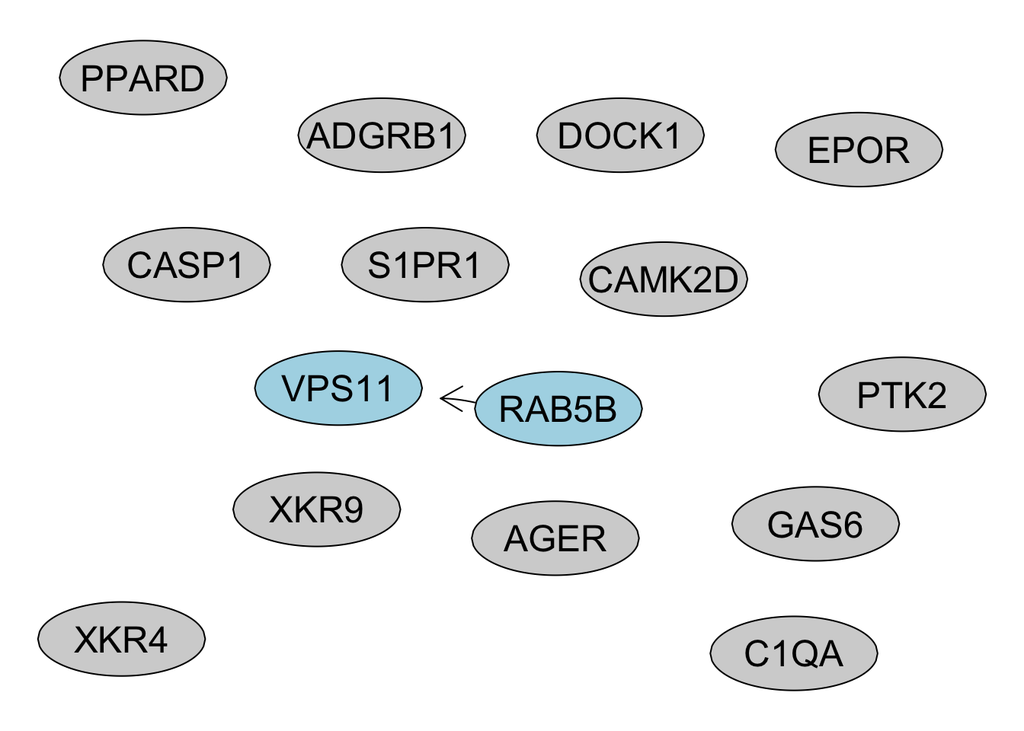

```r
# Read KEGG pathway file
map_kg <- parseKGML2Graph("KEGGgraph/data/hsa04148.xml", expandGenes = TRUE)
#map_file <- parseKGML("KEGGgraph/data/hsa04148.xml")

# Subset graph
map_sub <- subGraph(sample(nodes(map_kg), 15), map_kg)

# Nodes with in-degree (incoming edges; regulations received) and out-degree (regulations sent)
node_i <- sapply(inEdges(map_sub), length) > 0
node_o <- sapply(edges(map_sub), length) > 0
nodes_ios <- node_o | node_i

# Translate the KEGG IDs into gene names --- or use KOs?
if(suppressMessages(require(org.Hs.eg.db))) {
  node_io <- translateKEGGID2GeneID(names(nodes_ios))
  node_names <- sapply(mget(node_io, org.Hs.egSYMBOL, ifnotfound = NA), "[[", 1)
} else {
  node_names <- names(nodes_ios)
}
names(node_names) <- names(nodes_ios)

# Function to assign attributes (color) to specific nodes of a graph
makeAttr <- function(graph, default, valNodeList) {
  tmp <- nodes(graph)
  x <- rep(default, length(tmp))
  names(x) <- tmp

  if(!missing(valNodeList)) {
    stopifnot(is.list(valNodeList))
    allnodes <- unlist(valNodeList)
    stopifnot(all(allnodes %in% tmp))
    for(i in seq(valNodeList)) {
      x[valNodeList[[i]]] <- names(valNodeList)[i]
    }
  }
  return(x)
}

# Define node attributes
node_attrs <- list();
node_attrs$fillcolor <- makeAttr(map_sub, "lightgrey", list(lightblue = names(nodes_ios)[nodes_ios]))
node_attrs$label <- node_names

# Plot graph (using Rgraphviz)
plot(map_sub, "neato", nodeAttrs = node_attrs,
     attrs = list(node = list(width = "0.75", shape = "ellipse"),
                  edge = list(arrowsize = "0.7")))
```

```r
# Merge pathways: many KEGG pathways embed other pathway

# Betweenness is a centrality measure of a node within a graph
map_bcc <- RBGL::brandes.betweenness.centrality(map_kg)
map_bccval <- map_bcc$relative.betweenness.centrality.vertices[1L, ]

# Get top 5 genes by betweenness
top_bcc <- sort(map_bccval, decreasing = TRUE)[1:5]
print(top_bcc)
```

```
##  hsa:10461   hsa:5468   hsa:5879   hsa:5594   hsa:5595
## 0.12319635 0.12178205 0.10126475 0.08785757 0.08785757
```

```r
# Convert KEGG IDs to gene names
top_bccnames <- names(top_bcc)
top_bccid <- translateKEGGID2GeneID(top_bccnames)
top_bccgenes <- sapply(mget(top_bccid, org.Hs.egSYMBOL, ifnotfound = NA), "[[", 1)
print(top_bccgenes)
```

```
##   10461    5468    5879    5594    5595
## "MERTK" "PPARG"  "RAC1" "MAPK1" "MAPK3"
```

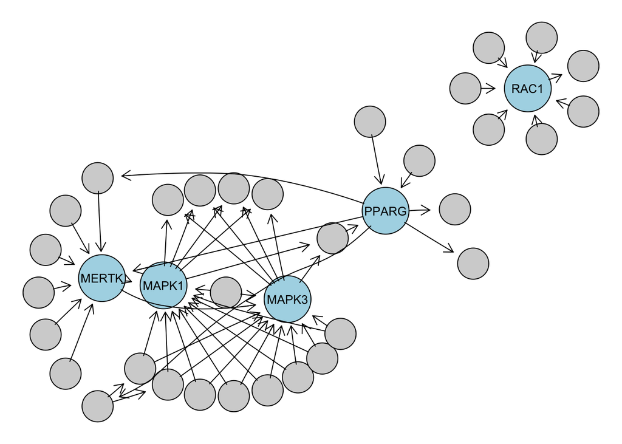

```r
# Subset graph by near nodes of top genes
top_in <- sapply(top_bccnames, function(x) inEdges(map_kg)[x])
top_out <- sapply(top_bccnames, function(x) edges(map_kg)[x])
top_subnodes <- unique(unname(c(unlist(top_in), unlist(top_out), top_bccnames)))
top_subg <- subGraph(top_subnodes, map_kg)

# Get gene names of subgraph
top_subnodes <- nodes(top_subg)
top_subids <- translateKEGGID2GeneID(top_subnodes)
top_subgenes <- sapply(mget(top_subids, org.Hs.egSYMBOL, ifnotfound = NA), "[[", 1)

# Plot subgraph of key genes
top_list <- unname(top_bccgenes)
top_lab <- lapply(top_bccnames, function(x) x)
names(top_lab) <- top_list
n_attrs <- list()
n_attrs$label <- makeAttr(top_subg, "", top_lab)
n_attrs$fillcolor <- makeAttr(top_subg, "lightgrey", list(lightblue = top_bccnames))
n_attrs$width <- makeAttr(top_subg, "", list("0.75" = top_bccnames))
#pdf("subgraph_efferocytosis.pdf", width = 9, height = 6)
plot(top_subg, "twopi", nodeAttrs = n_attrs, attrs = list(graph = list(start = 2)))
```

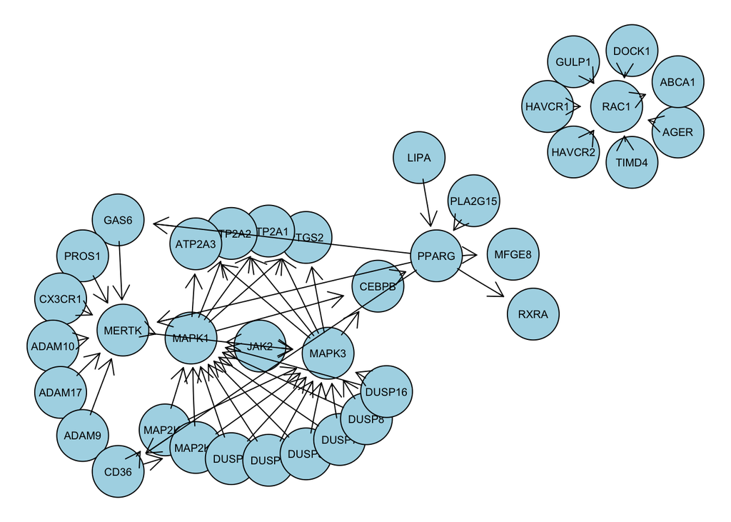

```r
#dev.off()

# v2
top_subg2 <- top_subg
nodes(top_subg2) <- top_subgenes
plot(top_subg2, "twopi", attrs = list(node = list(fillcolor = "lightblue", font = 5)))
```

```r
## check -> https://www.kegg.jp/pathway/hsa04148
```

## Gene expression per pathway

```r
#kegg_engenes
#get_gene_expression()
```

## Reactome pathway analysis

```r
#library(ReactomePA)
# Reactome Enrichment: gsePathway()
```